# OptiFit GLNE Exploratory

Courtney R Armour

Updated: 2022-02-07

### Overview of data splits

Since the random 80% training 20% testing splits are generated 100 times, we anticipate that if the samples are randomly assigned each one should appear in the training set about 80 of the 100 times (80%) and testing about 20 of the 100 times (20%). The plot below visualizes how many times each sample appears in the training and testing datasets.

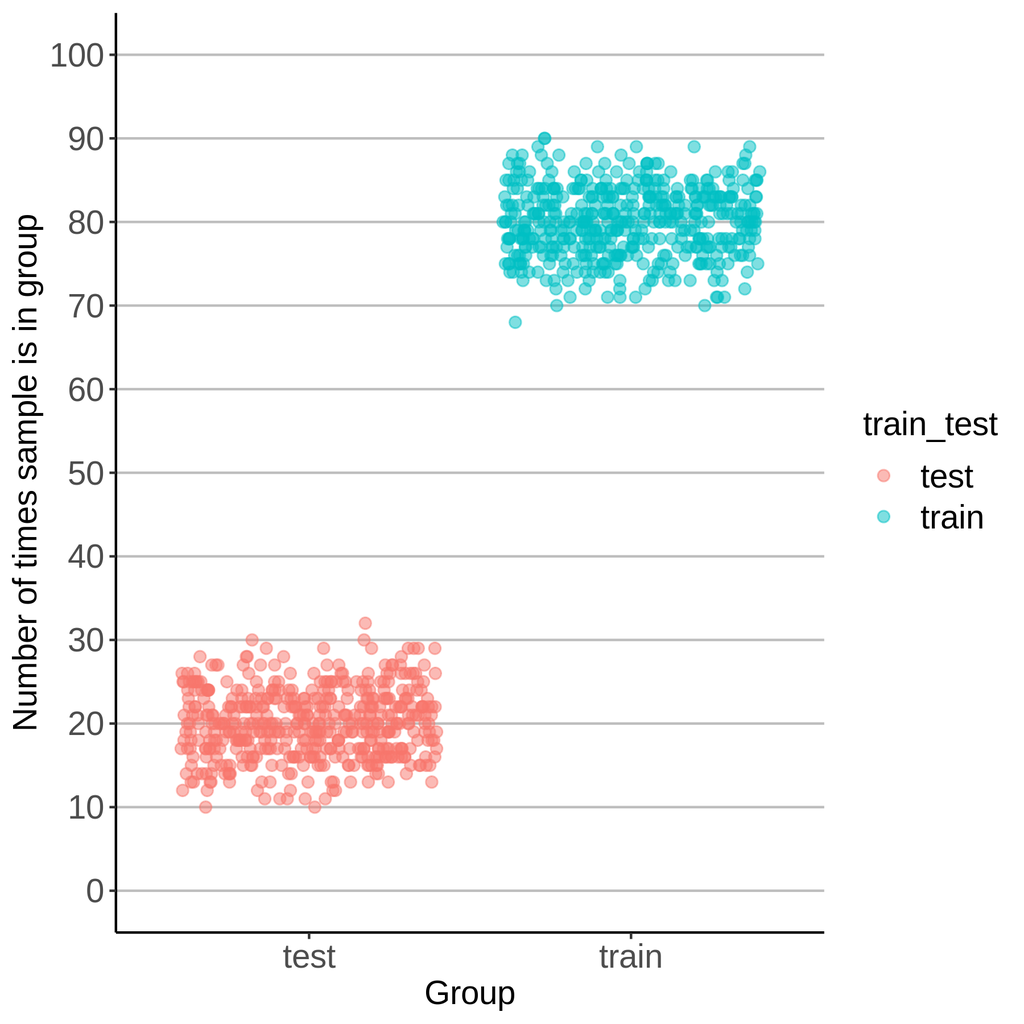

### MCC OptiFit vs OptiClust

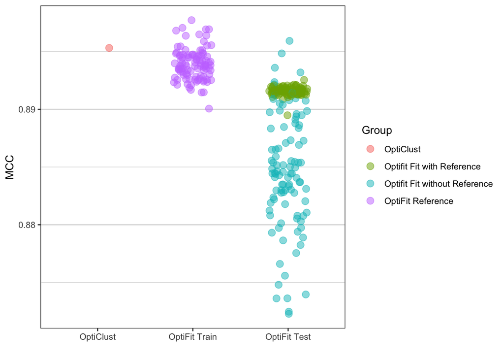

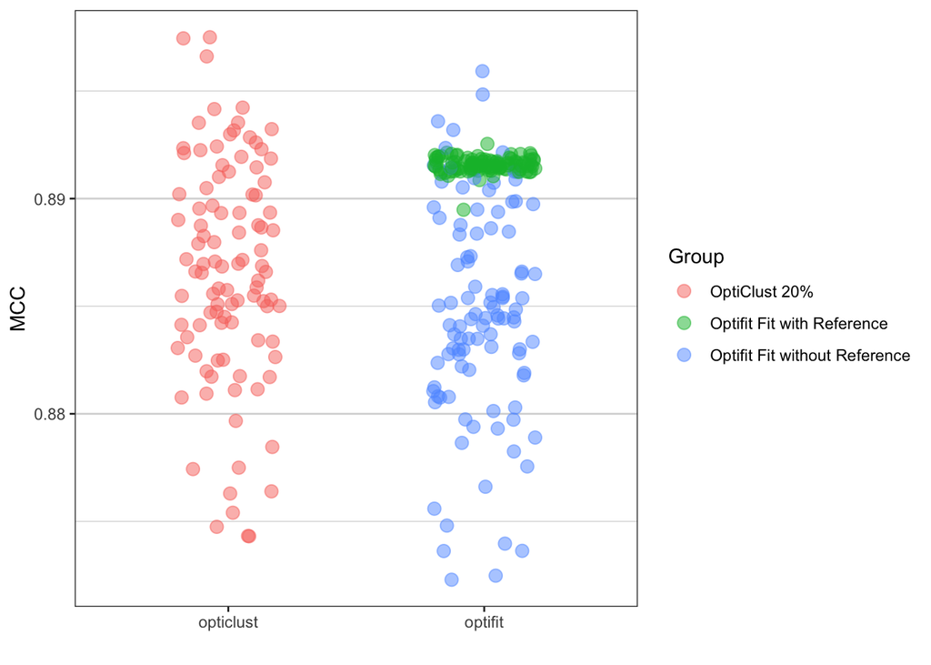

### HP performance

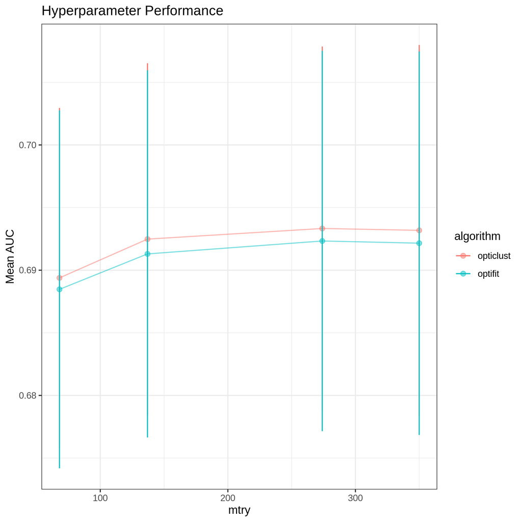

### Model performance during training

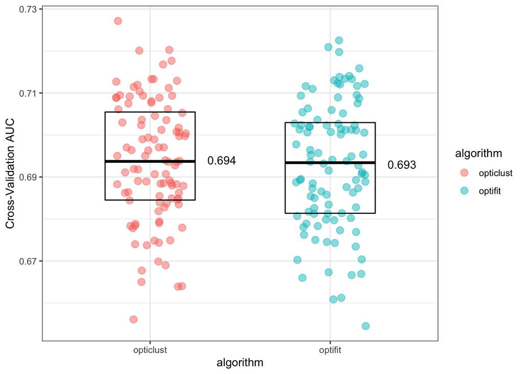

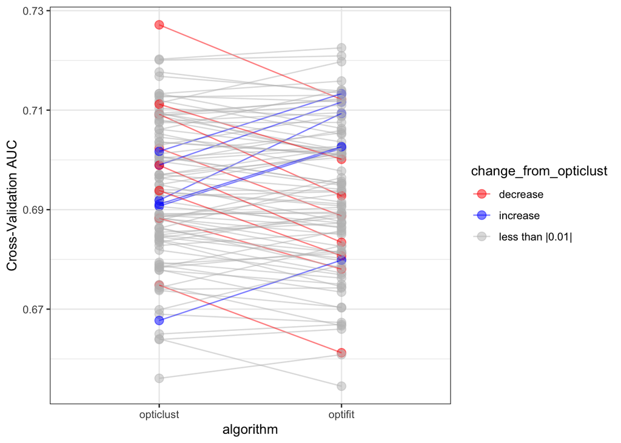

### Model performance on test data

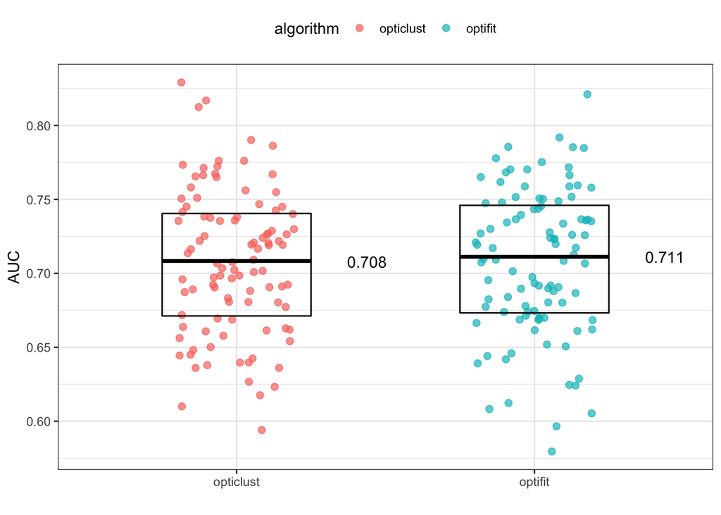

### Averaged ROC Curve

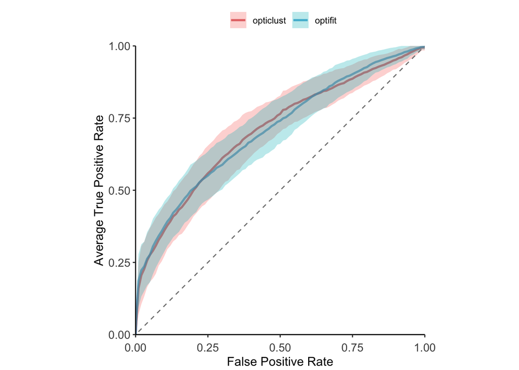

| Algorithm | Median AUC | Mean AUC |
| --- | --- | --- |
| opticlust | 0.708 | 0.708 |
| optifit | 0.711 | 0.708 |

### Correct Classification Frequency

For each split, a cutoff of 0.5 was used to determine whether each sample was correctly or incorrectly classified. This data was merged for all splits to quantify the percent of splits each sample was correctly classified in. For normal samples it is the frequency that sample was a true negative and for cancer samples its the frequency that sample was a true positive. For example, if a cancer sample had a probabily of being cancer greater than 0.5 for 10 of the 20 splits it was in the test set for, it would have a percent correct value of 50%. I’m trying to figure out how to visualize this data…

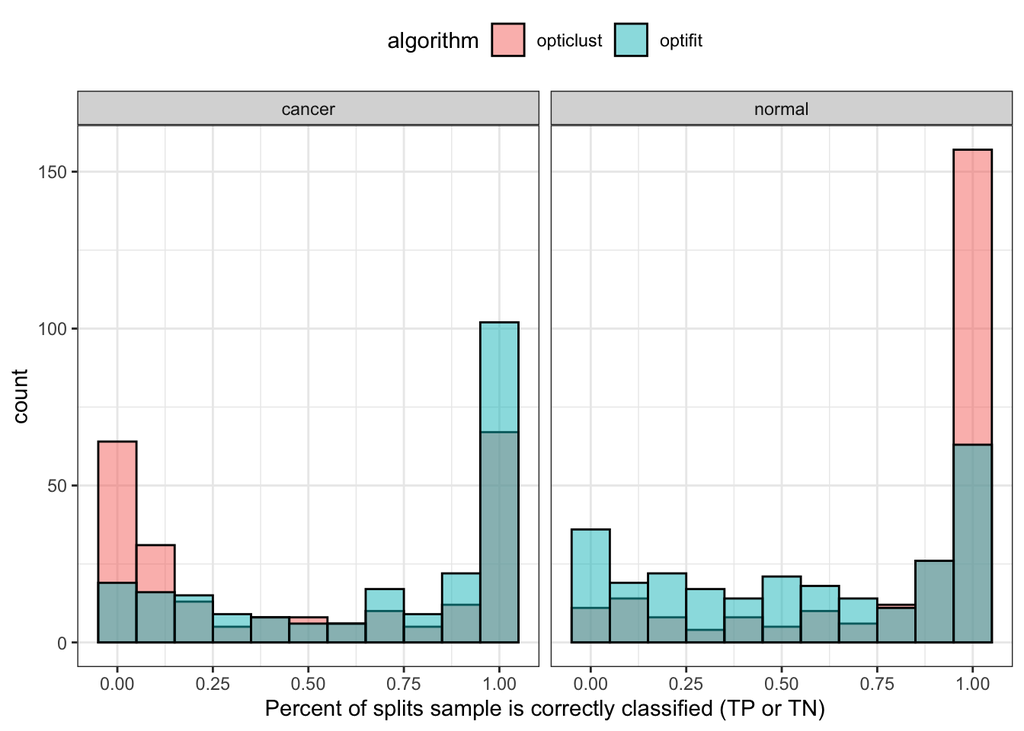

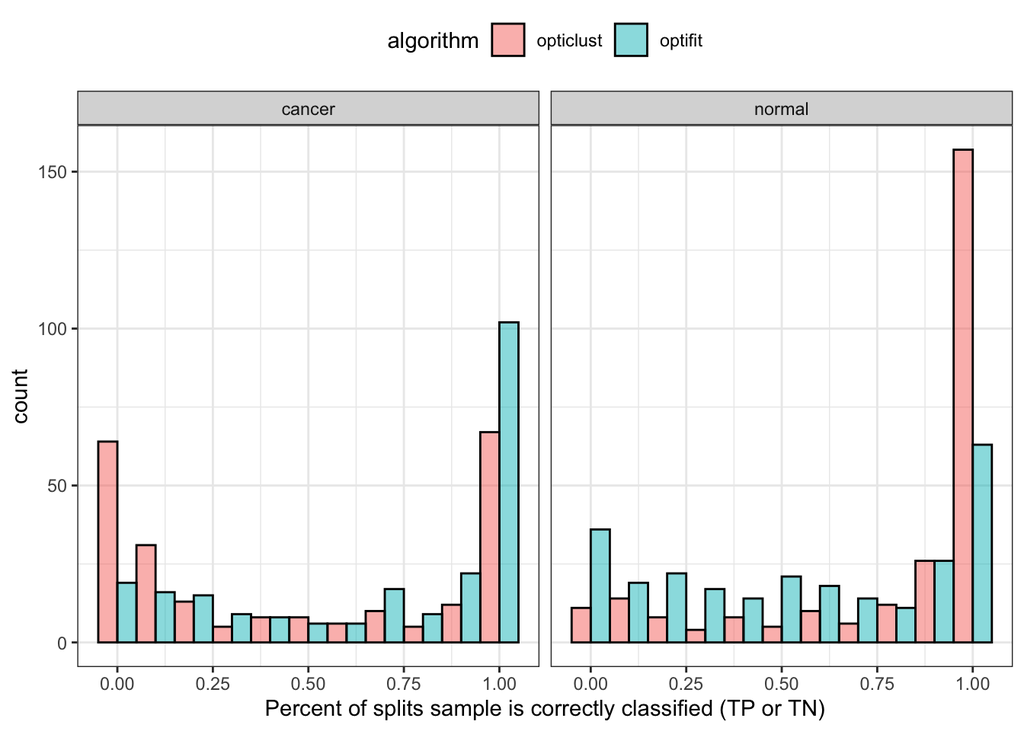

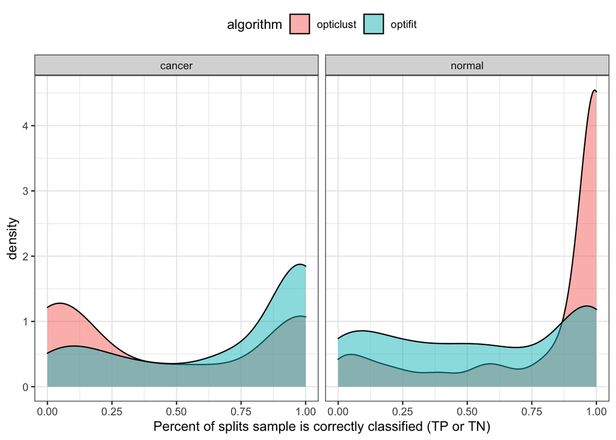

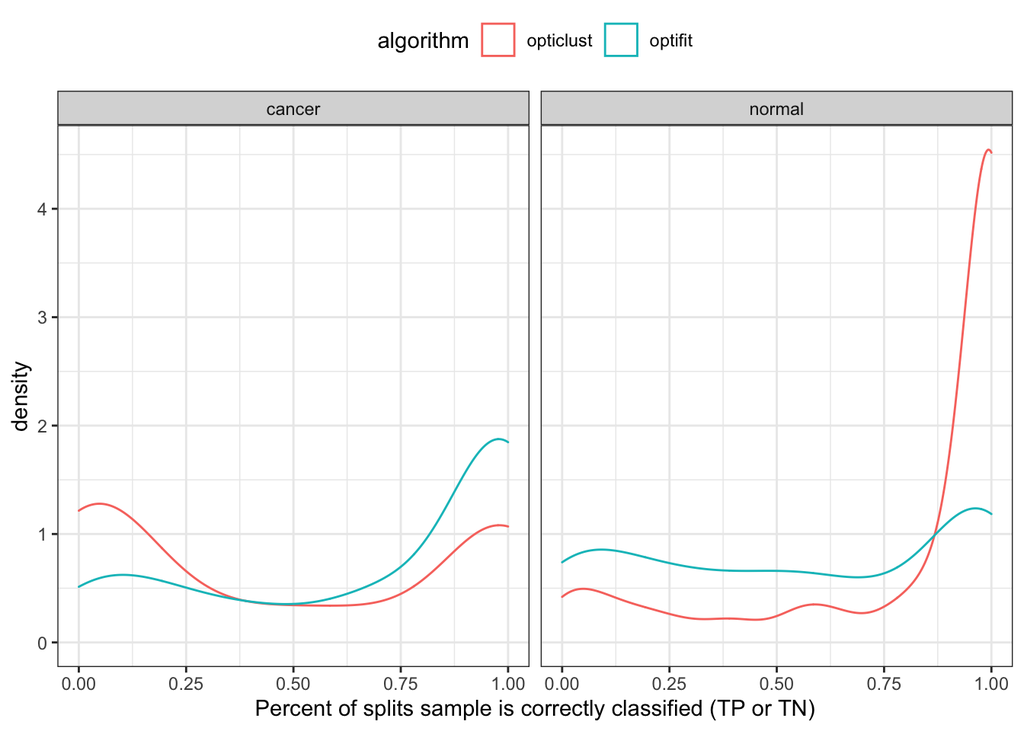

The scatter plot below has the samples along the x-axis without labels because they are not readable. The y-axis is the percent correct. The color of the points is the algorithm. There is a separate plot for cancer samples and normal samples.

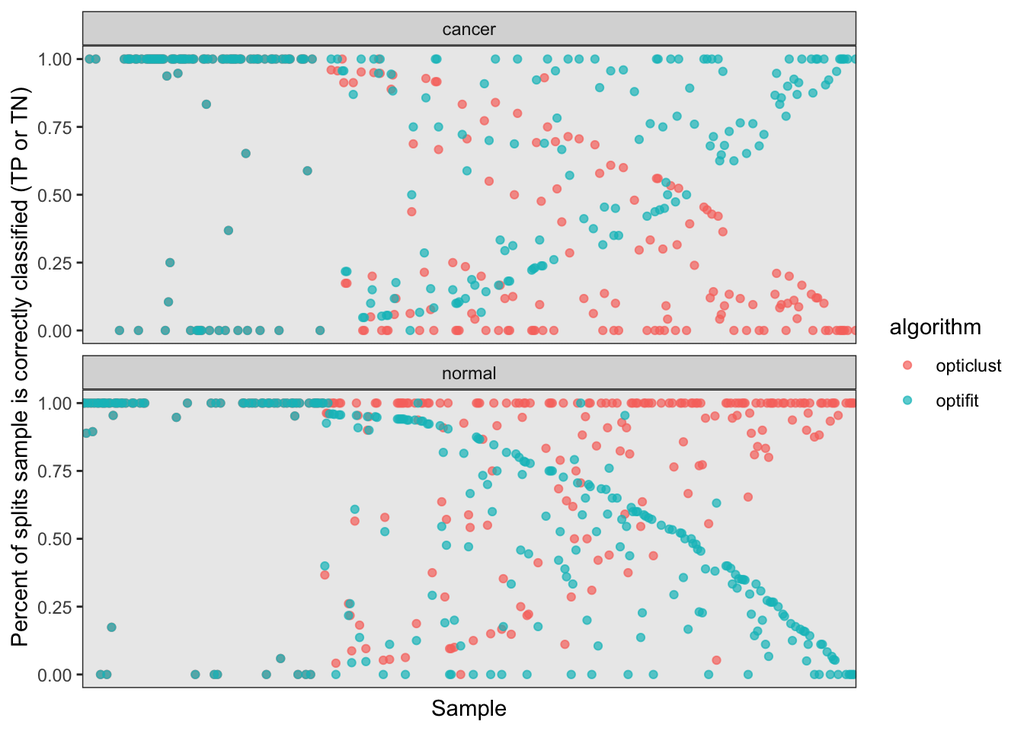

To eliminate some noise, I removed any samples where there was no difference in the percent correct between the two algorithms.

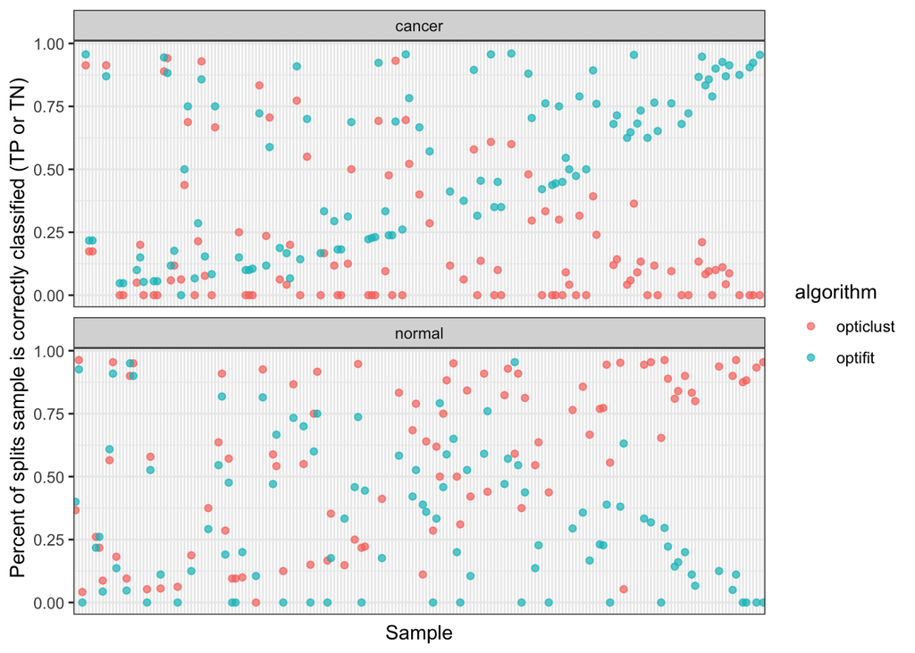